# Chapter 5: Controlled comparisons

# Reminders

- Homework due this week
- Survey:
  - Don’t circulate anything yet! I’ll be making edits to the class survey and then providing everyone with a new link
  - At the end of the week, I’ll share some results from the pilot and you’ll be asked to do some basic analyses of the results.

# Reminders

# Confounding and spuriousness

A spurious correlation occurs when X and Y appear to be correlated but a third variable (the confounder) actually accounts for both.

## Spurious Relationships

Why might we see a correlation between the amount of weekly protest activity and the number of flights to Hawaii?

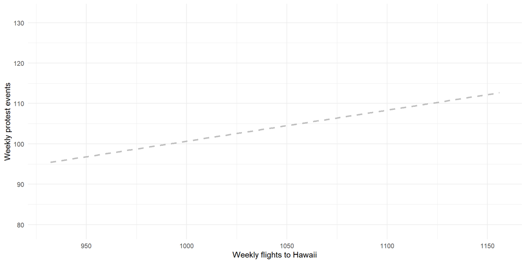

## Spurious Relationships

The spurious correlation is happening because summer days have more protests **and** more flights to Hawaii because that’s when the weather is nice.

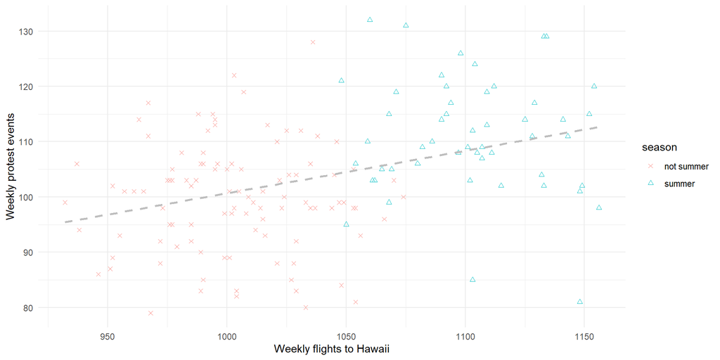

How do we resolve this?

## Spurious Relationships

- A simple fix here would be dis-aggregation: we split the data up based on the season and then we re-assess the same relationship within each group. This would ensure we were comparing summer flights to summer protests and non-summer flights to non-summer protests.
- If the correlation is spurious, then this will make the observed relationship will disappear or potentially even reverse (go from positive to negative or vice-versa)

## Spurious Relationships

- This process of splitting data up to make comparisons within groups is the basic intuition behind mathematically controlling for a confounder. (you’ll often hear this described as “holding constant” for a confounder)

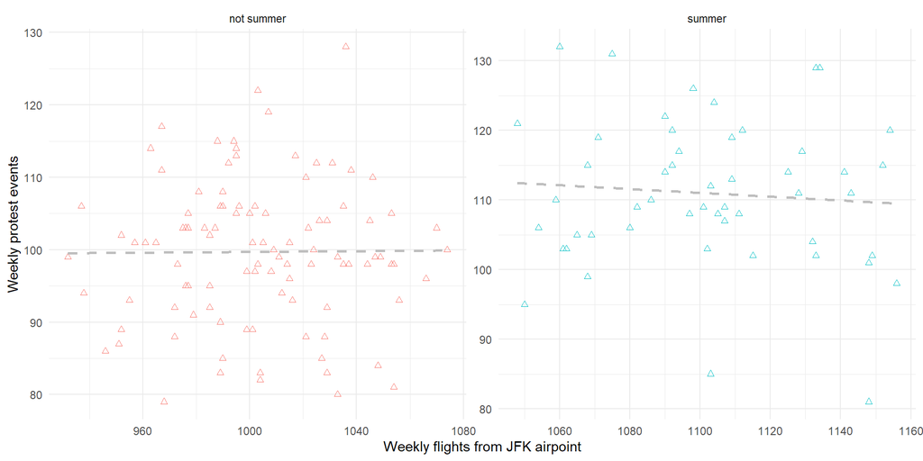

# Controlled Comparison: CRA vote

| CRA vote | Dem | Rep |
| --- | --- | --- |
| yes | 153 (63%) | 136 (80%) |
| no | 91 (37%) | 35 (20%) |

## 1964 CRA vote

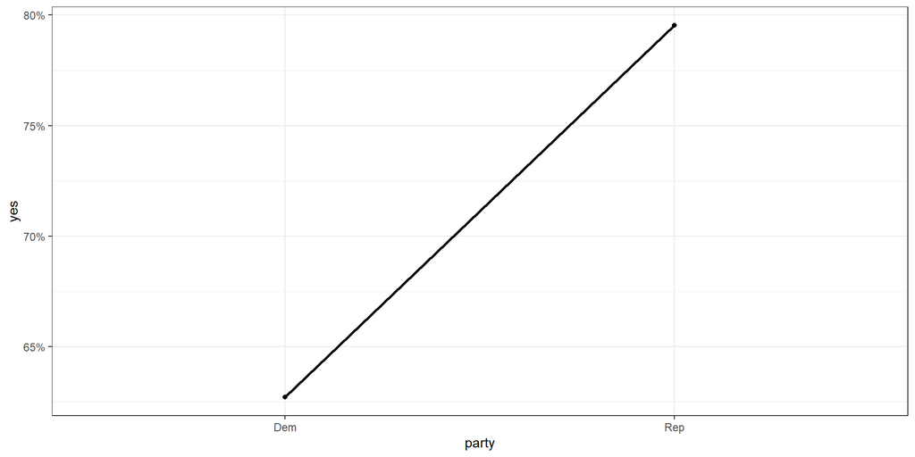

## 1964 CRA vote

[figure not shown]

## 1964 CRA vote

The pattern looks different once we consider region:

- Effect of party in the north = 95 - 85 = 10
- Effect of party in the south = 9 - 0 = 9
- The relationship flips direction and shrinks after accounting for region.

|  | North |  | South |  |
| --- | --- | --- | --- | --- |
| CRA vote | Dem | Rep | Dem | Rep |
| yes | 145 (95%) | 136 (85%) | 8 (9%) | 0 (0%) |
| no | 8 (5%) | 24 (15%) | 83 (91%) | 11 (100%) |

## 1964 Civil Rights Act

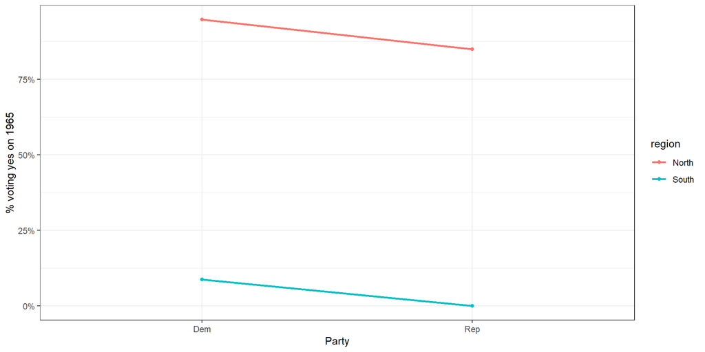

## Control groups vs. Control variables

- The language here tends to throw people off:
  - **Control groups** are the baseline group in an experiment. The control group in a medical study would be the people who received the placebo treatment.
  - **Control variables** are the confounding variables that we want to address by holding constant for their effects on the outcome.

Randomization and control variables attempt to accomplish the same goals, but in different ways.

# Terminology

- **Dependent variable(s):** the outcome of interest.
- **Independent variable(s):** the main explanatory variable
- **Control variable(s):** additional variables included to account for confounding

[figure not shown]

# Describing three-way relationships

There are three potential outcomes we might see when examining a relationship after controlling for another variable:

- **Spurious:** controlling for Z accounts for the entire correlation between X and Y
- **Additive:** Z also impacts Y
- **Interactive:** Z modified the effect of X on Y

## Additive Relationships

In an additive relationship, Z independently influences the outcome, but it doesn’t account for the relationship between X and Y

Examples:

- Being Republican and conservative both make people more likely to vote for Republican candidates.
- GDP and literacy rates both make countries more likely to be Democratic.
- Genetics and environment both impact life expectancy separately.

### Additive Relationships

Additive relationships will look like two roughly parallel lines with the same slope but different intercepts:

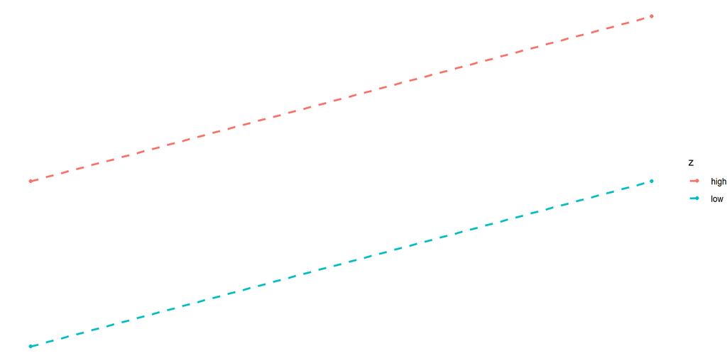

### Additive Relationships

Additive relationships are different from confounders. Other variables may matter for the outcome, **but they don’t bias our ability to estimate the effect of the IV on the DV.** (the slope here is the same with or without the control)

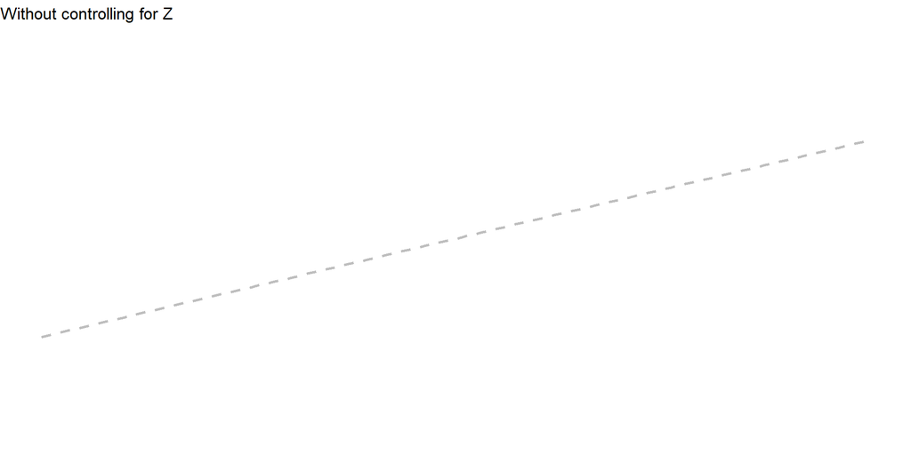

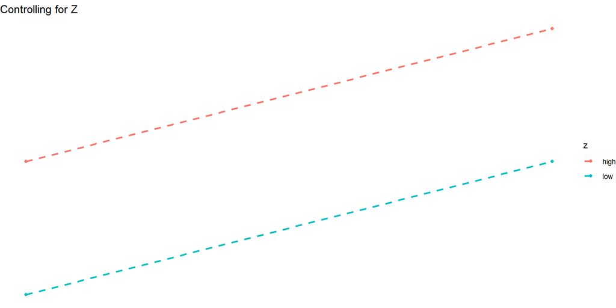

### Additive Relationships

(In practice, two lines may only be *approximately* parallel)

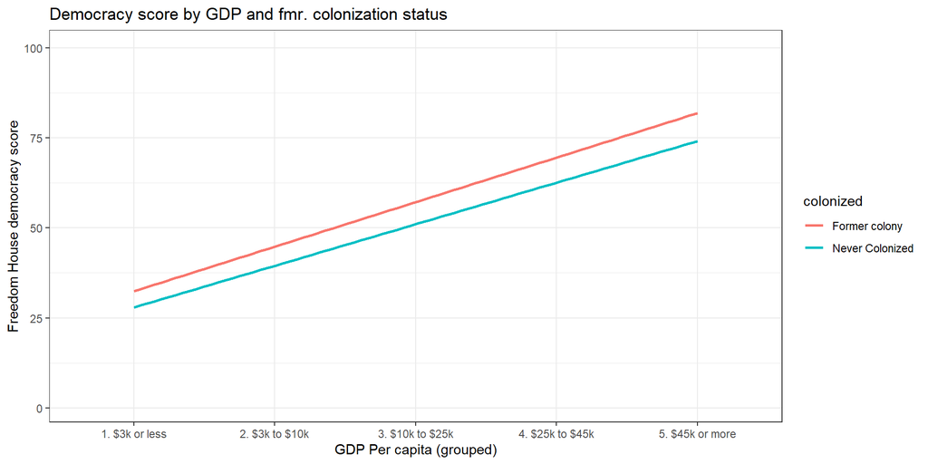

## Interactive Relationship

In an interactive relationship, Z strengthens or weakens the effect of X on Y.

- Weight changes the effect of alcoholic drinks on blood alcohol level. (smaller people get drunk with fewer drinks, all else equal)
- Issue salience makes policy views more important. (i.e. if a candidate talks a lot about abortion, abortion opinions will matter **more** for vote choice)
- State referenda make state policy more likely to align with public opinion.

### Interactive Relationships

Interactive relationships will look like two distinctly non-parallel lines:

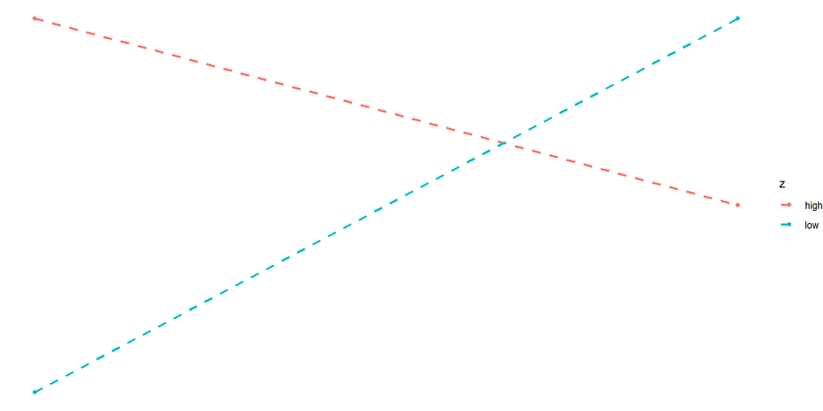

### Interactive Relationships

For instance: the effect of strong religious views on party ID and voting behavior is different for white and black respondents.

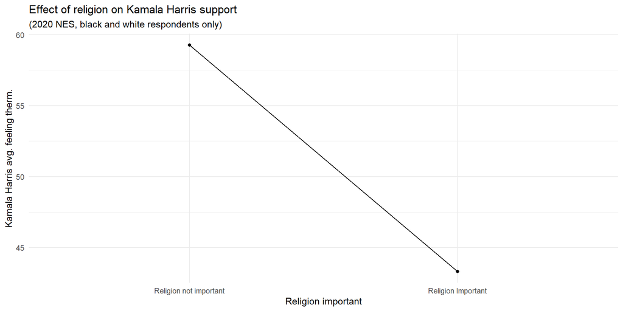

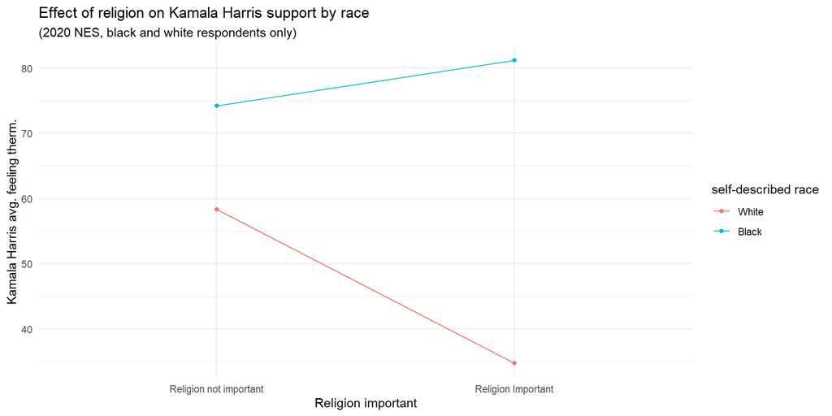

# Notes

- In practice, we will often have more than one IV and more than one control because lots of things can be explanatory.
- Your proposed control may be someone else’s main IV. This isn’t a property of a theorized relationship, not an intrinsic feature of any variable.
- Our goal isn’t necessarily to account for everything. Accounting for confounders is very important. Accounting for additive relationships is not especially important.
- More controls = less data. We’re “splitting” data up by levels of multiple confounder, at a certain point we don’t have enough observations in any one group to say anything useful.

# Limitations

Why are experiments still preferable to mathematical controls?

- Randomization can **guarantee** there’s no confounding
- Mathematical controls only works if:
  - We know what the confounder is
  - We can measure it
  - We have enough data to make meaningful comparisons after dis-aggregation

# Controlled Comparisons

## Using a cross-tab

### Using a cross-tab: effect of party

First, get the effect of the IV within each value of the control.

Gun control by party ID, controlling for gender

| Gun Control | Women Dem | Women Rep | Men Dem | Men Rep |
| --- | --- | --- | --- | --- |
| Oppose | 301 (20%) | 825 (74%) | 299 (29%) | 962 (83%) |
| Support | 1177 (80%) | 297 (26%) | 716 (71%) | 204 (17%) |

### Using a cross-tab: effect of party

First, get the effect of the IV *within each value of the control.*

Effect of Democrat vs. Republican for Women:
$$20 - 74 = -54$$

Gun control by party ID, controlling for gender

| Gun Control | Women Dem | Women Rep | Men Dem | Men Rep |
| --- | --- | --- | --- | --- |
| Oppose | 301 (20%) | 825 (74%) | 299 (29%) | 962 (83%) |
| Support | 1177 (80%) | 297 (26%) | 716 (71%) | 204 (17%) |

### Using a cross-tab: effect of party

First, get the effect of the IV *within each value of the control.*

Effect of Democrat vs. Republican for Women:
$$20 - 74 = -54$$

Gun control by party ID, controlling for gender

| Gun Control | Women Dem | Women Rep | Men Dem | Men Rep |
| --- | --- | --- | --- | --- |
| Oppose | 301 (20%) | 825 (74%) | 299 (29%) | 962 (83%) |
| Support | 1177 (80%) | 297 (26%) | 716 (71%) | 204 (17%) |

### Using a cross-tab: effect of party

First, get the effect of the IV *within each value of the control.*

Effect of Democrat vs. Republican for Women:
$$20 - 74 = -54$$

Effect of Democrat vs. Republican for Men:
$$29 - 83 = -54$$

If they’re different, you can average the two effects to get a rough summary of the impact of the IV on the DV after controlling for “Z”

Gun control by party ID, controlling for gender

| Gun Control | Women Dem | Women Rep | Men Dem | Men Rep |
| --- | --- | --- | --- | --- |
| Oppose | 301 (20%) | 825 (74%) | 299 (29%) | 962 (83%) |
| Support | 1177 (80%) | 297 (26%) | 716 (71%) | 204 (17%) |

### Using a cross-tab: effect of gender

First, get the effect of the Z *within each value of the IV*

Effect of Women vs. Men for Democrats
$$20 - 29 = -9$$

Gun control by party ID, controlling for gender

| Gun Control | Women Dem | Women Rep | Men Dem | Men Rep |
| --- | --- | --- | --- | --- |
| Oppose | 301 (20%) | 825 (74%) | 299 (29%) | 962 (83%) |
| Support | 1177 (80%) | 297 (26%) | 716 (71%) | 204 (17%) |

### Using a cross-tab: effect of gender

First, get the effect of the Z *within each value of the IV*

Effect of Women vs. Men for Democrats
$$20 - 29 = -9$$

Effect of Women vs. Men for Republicans
$$74 - 83 = -9$$

Gun control by party ID, controlling for gender

| Gun Control | Women Dem | Women Rep | Men Dem | Men Rep |
| --- | --- | --- | --- | --- |
| Oppose | 301 (20%) | 825 (74%) | 299 (29%) | 962 (83%) |
| Support | 1177 (80%) | 297 (26%) | 716 (71%) | 204 (17%) |

### Using a cross-tab

Partial Effect of party =
$$(-54 + -54) / 2 = -54$$

Partial Effect of gender =
$$(-9 + -9) / 2 = -9$$

Gun control by party ID, controlling for gender

| Gun Control | Women Dem | Women Rep | Men Dem | Men Rep |
| --- | --- | --- | --- | --- |
| Oppose | 301 (20%) | 825 (74%) | 299 (29%) | 962 (83%) |
| Support | 1177 (80%) | 297 (26%) | 716 (71%) | 204 (17%) |

## Identifying the pattern

To characterize the pattern after control, you can ask yourself a series of questions.

### Identifying the pattern: Question 1

- Question 1: Does a relationship exist between the IV, DV in at least one value of the control variable?
  - If not, then the relationship is spurious
  - If so, then go to the next question

### Identifying the pattern: Question 2

- Question 2: is the **direction** of the relationship between the IV and the DV about the same for all values of the control?
  - If no, then this is an **interaction**
  - If yes, then go to the next question

### Identifying the pattern: Question 3

- Question 3: is the **strength** of the relationship between the IV and the DV the same for all values of the control?
  - If no, then this is an **interaction**
  - If yes, then the relationship is additive

### Identifying the pattern: gun control

- Question 1: Does a relationship exist between the IV, DV in at least one value of the control variable?
- Question 2: is the **direction** of the relationship between the IV and the DV about the same for all values of the control?
- Question 3: is the **strength** of the relationship between the IV and the DV the same for all values of the control?

Gun control by party ID, controlling for gender

| Gun Control | Women Dem | Women Rep | Men Dem | Men Rep |
| --- | --- | --- | --- | --- |
| Oppose | 301 (20%) | 825 (74%) | 299 (29%) | 962 (83%) |
| Support | 1177 (80%) | 297 (26%) | 716 (71%) | 204 (17%) |

### Identifying the pattern: the economy

- What is the effect of age on belief that the economy has gotten worse?

Dems:
$$36 - 24 = 12$$

Independents:
$$66 - 80 = -14$$

Republicans:
$$85 - 79 = 6$$

State of the economy since last year by age and party ID Source: ANES 2024

|  | Democrats 18-65 | Democrats 65+ | Independents 18-65 | Independents 65+ | Republicans 18-65 | Republicans 65+ |
| --- | --- | --- | --- | --- | --- | --- |
| better | 371 (33%) | 165 (53%) | 22 (9%) | 2 (8%) | 38 (4%) | 16 (6%) |
| same | 341 (31%) | 69 (22%) | 62 (25%) | 3 (12%) | 113 (11%) | 43 (15%) |
| worse | 404 (36%) | 75 (24%) | 160 (66%) | 19 (80%) | 849 (85%) | 221 (79%) |

### Identifying the pattern: the economy

- Question 1: Does a relationship exist between the IV, DV in at least one value of the control variable?
- Question 2: is the **direction** of the relationship between the IV and the DV about the same for all values of the control?
- Question 3: is the **strength** of the relationship between the IV and the DV the same for all values of the control?

State of the economy since last year by age and party ID Source: ANES 2024

|  | Democrats 18-65 | Democrats 65+ | Independents 18-65 | Independents 65+ | Republicans 18-65 | Republicans 65+ |
| --- | --- | --- | --- | --- | --- | --- |
| better | 371 (33%) | 165 (53%) | 22 (9%) | 2 (8%) | 38 (4%) | 16 (6%) |
| same | 341 (31%) | 69 (22%) | 62 (25%) | 3 (12%) | 113 (11%) | 43 (15%) |
| worse | 404 (36%) | 75 (24%) | 160 (66%) | 19 (80%) | 849 (85%) | 221 (79%) |

## Mean comparison table

### Mean comparison table

For mean comparisons, calculate the difference going from bottom to top (or top to bottom)

Feeling thermometer: LGBT people

| Party ID | Mean FT |
| --- | --- |
| Dem | 74.1 (2865) |
| Rep | 52.8 (2602) |

### Mean comparison table

For controlled mean comparisons, calculate the average effect at each value of the control.

$57.8 - 77.8 = -20$

$53.6 - 73.3 = -19.7$

$48.4 - 71.3 = -22.9$

Mean partial effect of Party ID controlling for age: $-21$

Feeling thermometer: LGBT people

| Party ID | 18-39 | 39-59 | 60+ |
| --- | --- | --- | --- |
| Dem | 77.8 (959) | 73.3 (866) | 71.3 (914) |
| Rep | 57.8 (666) | 53.6 (887) | 48.4 (923) |

### Mean comparison table

- Question 1: Does a relationship exist between the IV, DV in at least one value of the control variable?
- Question 2: is the **direction** of the relationship between the IV and the DV about the same for all values of the control?
- Question 3: is the **strength** of the relationship between the IV and the DV the same for all values of the control?

Feeling thermometer: LGBT people

| Party ID | 18-39 | 39-59 | 60+ |
| --- | --- | --- | --- |
| Dem | 77.8 (959) | 73.3 (866) | 71.3 (914) |
| Rep | 57.8 (666) | 53.6 (887) | 48.4 (923) |

## Nominal Relationships

- For data that are nominal, it may not make sense to talk about the “direction”, but your book suggests using treating the left-most category as the baseline group and then comparing based on that.

% unionization

| iv | South | Northeast | Midwest | West |
| --- | --- | --- | --- | --- |
| Biden 20 | 7.6 (4) | 14.4 (9) | 12.8 (4) | 12.4 (8) |
| Trump 20 | 5.9 (12) | 0 (0) | 8.5 (8) | 9.5 (5) |

## When to use what

- Use a cross tab when all variables are categorical
- Use a mean comparison when the DV is interval and the control and IV are categorical
  - Keep in mind that, if the DV is dichotomous, you can basically treat it as numeric and the “mean” is equal to the proportion of “Yes” or “TRUE” values for each group.
- Consider collapsing some categories to simplify analyses and ensure you have sufficient data. For instance, if a response ranges from Strongly Agree to Strongly Disagree, you might collapse it down to just 2-3 categories.

## What about interval level relationships?

- You can collapse interval data into categories and then use a mean comparison
- More often, we’ll use **regression analysis:**
  - In essence, we’ll draw a “line of best fit” through the values of X and Y

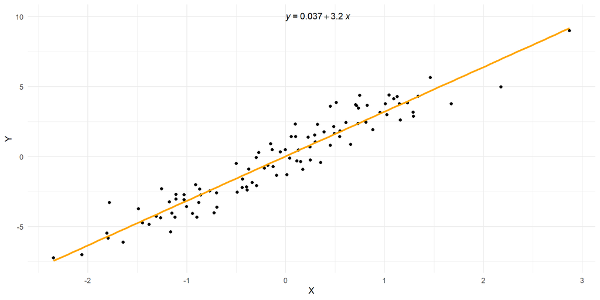

## Other methods for addressing confounding

## Matching

- Identify similar cases at each level of the IV. For instance, find Republicans and Democrats of similar ages.
- Drop any cases that can’t be matched.
- Re-weight the cases to ensure balance, and then assess the effect.

## Difference-in-differences

- Measure outcomes for two groups at two different times
- If you can assume the trend for both groups is the same, then the difference-in-differences at time 2 is the effect of the treatment.

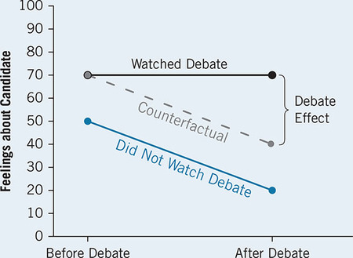

# Information about the midterm

- **March 12**
  - Online as an ELMS quiz
  - Becomes available at 8 AM
  - Must be finished by 4 PM
  - Once you start, you’ll have one hour to complete (if you start at 3:30, that only leaves you with 30 minutes, so don’t do that)

# Information about the midterm

- All fill in the blank/multiple choice
- ~30 questions
- Covers materials from chapters 1 - 5
  - Textbook is likely the best source, but pay especially close attention to stuff that appears in both the textbook and the lecture.
- I’ll post a list of key concepts this week, and next Monday (3/10) we’ll have a Q & A session to prep

# Pilot Analysis

- [Link to script](https://raw.githubusercontent.com/Neilblund/GVPT-201-Site/refs/heads/main/R%20code/pilot_analysis_script.R)
- [Link to codebook](https://neilblund.github.io/GVPT-201-Site/pilot_codebook.html)